# Part I - Ford GoBike Data Exploration

## Introduction

This data set includes information about individual rides made in a [bike-sharing](https://www.moneycrashers.com/bike-sharing-best-bike-share-programs/) system covering the greater San Francisco Bay area within the month of February, 2019 ([source](https://en.wikipedia.org/wiki/Bay_Wheels)).

The idea behind bike sharing is to enjoy the joys of riding a bike around a city without needing to own one. The bikes are of high quality, too. Bike-sharing is essentialy a bicycle rental program. It's like renting a car, but the object being rented is a bicycle. For this particular dataset, the rental program (called Bay Wheels initially, later renamed to Ford GoBike) offers bike rentals 24 hours a day, 7 days a week, all-year round. Thus, we should expect to see at least one night-time rental in our dataset.

For our purposes, we'll refer to all trip-takers (people who rented the bikes and took the trips) as 'users'. Rentals will also be referred to as 'trips'. We obviously don't have enough information to know the 'true' duration of each journey. In this dataset, a 'trip' simply means the time the rental started and the time it officially ended. It also includes information about the rental stations.

## The Dataset's variables

- **bike_id** - an integer identifying the bike that was rented.
- **member_birth_year** - the year in which the user was born.
- **member_gender** - the user's gender.
- **user_type** - what rental plan did the particular user follow? Two unique values here - Customer and Subscriber. Customers rent the bikes for a day or less, while Subscribers are subscribed to longer-term rental plans like a month or up to a year.
- **[bike_share_for_all_trip](https://www.lyft.com/bikes/bay-wheels/bike-share-for-all)** - this is a rental plan which is more affordable than the single-trip or single-day rental, though not as cheap as the full membership.
- **start_time** - what time did the trip start?
- **end_time** - what time did the trip end?
- **duration_sec** - useful summary information telling us how long the trip lasted.
- **start_station_id, start_station_name** - information identifying the station where the bike was rented from.
- **start_station_latitude, start_station_longitude** - information identifying the geographic location of the start station.
- **end_station_id, end_station_name** - information identifying the station where the bike was dropped at (thus ending the trip).
- **end_station_latitude, end_station_longitude** - information identifying the geographic location of the end station.

## Preliminary Wrangling

Before exploring, we'll have to prepare the dataset by cleaning it and presenting some of the information in a more useful format.

```python
# import all packages and set plots to be embedded inline
import datetime as dtime
import numpy as np
import pandas as pd
import matplotlib.pyplot as plt
import os
import seaborn as sb

%matplotlib inline
```

```python
# read the csv file
df_ford = pd.read_csv('fordgobike-tripdata.csv')
```

```python
# observe five random rows to get a feel for the dataset
df_ford.sample(5,random_state=10)
```

|  | duration_sec | start_time | end_time | start_station_id | start_station_name | start_station_latitude | start_station_longitude | end_station_id | end_station_name | end_station_latitude | end_station_longitude | bike_id | user_type | member_birth_year | member_gender | bike_share_for_all_trip |
| --- | --- | --- | --- | --- | --- | --- | --- | --- | --- | --- | --- | --- | --- | --- | --- | --- |
| 103338 | 241 | 2019-02-14 13:35:33.8230 | 2019-02-14 13:39:35.8010 | 386.0 | 24th St at Bartlett St | 37.752105 | -122.419724 | 132.0 | 24th St at Chattanooga St | 37.751819 | -122.426614 | 6593 | Subscriber | 1995.0 | Female | No |
| 145015 | 446 | 2019-02-07 10:24:08.5560 | 2019-02-07 10:31:34.9250 | 100.0 | Bryant St at 15th St | 37.767100 | -122.410662 | 126.0 | Esprit Park | 37.761634 | -122.390648 | 5050 | Subscriber | 1986.0 | Male | No |
| 152618 | 1016 | 2019-02-06 15:06:40.1410 | 2019-02-06 15:23:36.6420 | 104.0 | 4th St at 16th St | 37.767045 | -122.390833 | 132.0 | 24th St at Chattanooga St | 37.751819 | -122.426614 | 4611 | Subscriber | 1973.0 | Male | No |
| 127410 | 311 | 2019-02-10 15:58:33.0940 | 2019-02-10 16:03:44.1530 | 179.0 | Telegraph Ave at 27th St | 37.816073 | -122.267886 | 179.0 | Telegraph Ave at 27th St | 37.816073 | -122.267886 | 5414 | Subscriber | 1981.0 | Male | No |
| 68876 | 716 | 2019-02-19 20:45:51.2990 | 2019-02-19 20:57:47.5090 | 89.0 | Division St at Potrero Ave | 37.769218 | -122.407646 | 120.0 | Mission Dolores Park | 37.761420 | -122.426435 | 6474 | Subscriber | 1983.0 | Male | No |

From cursory observation we note...

- The start and end times have more precision than we need
- The station id's are stored as floats rather than integers

Let's check for missing values.

```python
# Let's look at summary statistics
df_ford.describe()
```

|  | duration_sec | start_station_id | start_station_latitude | start_station_longitude | end_station_id | end_station_latitude | end_station_longitude | bike_id | member_birth_year |
| --- | --- | --- | --- | --- | --- | --- | --- | --- | --- |
| count | 183412.000000 | 183215.000000 | 183412.000000 | 183412.000000 | 183215.000000 | 183412.000000 | 183412.000000 | 183412.000000 | 175147.000000 |
| mean | 726.078435 | 138.590427 | 37.771223 | -122.352664 | 136.249123 | 37.771427 | -122.352250 | 4472.906375 | 1984.806437 |
| std | 1794.389780 | 111.778864 | 0.099581 | 0.117097 | 111.515131 | 0.099490 | 0.116673 | 1664.383394 | 10.116689 |
| min | 61.000000 | 3.000000 | 37.317298 | -122.453704 | 3.000000 | 37.317298 | -122.453704 | 11.000000 | 1878.000000 |
| 25% | 325.000000 | 47.000000 | 37.770083 | -122.412408 | 44.000000 | 37.770407 | -122.411726 | 3777.000000 | 1980.000000 |
| 50% | 514.000000 | 104.000000 | 37.780760 | -122.398285 | 100.000000 | 37.781010 | -122.398279 | 4958.000000 | 1987.000000 |
| 75% | 796.000000 | 239.000000 | 37.797280 | -122.286533 | 235.000000 | 37.797320 | -122.288045 | 5502.000000 | 1992.000000 |
| max | 85444.000000 | 398.000000 | 37.880222 | -121.874119 | 398.000000 | 37.880222 | -121.874119 | 6645.000000 | 2001.000000 |

From the above statistics, we can see a problem with the member_birth_years column - one user was born in 1878 apparently. We can also see a problem with the trip duration (seconds). The maximum is about 85,444 seconds which is about 23 hours long. It's unlikely that any person rode a bicycle straight for 23 hours (even if it's an automatic bicycle), so that value suggests a slight flaw in how we interpret the trip duration data.

Once again, the trip duration only represents the time between when the rental was started, and when it was ended. It's entirely possible that a user started their rental, went and stayed home for 24 hours then ended their rental the next day! Still, let's have faith that most of the trips were fairly 'normal'. Let's explore the data some more.

```python
# are the datatypes appropriate?
df_ford.dtypes
```

```
duration_sec                 int64
start_time                  object
end_time                    object
start_station_id           float64
start_station_name          object
start_station_latitude     float64
start_station_longitude    float64
end_station_id             float64
end_station_name            object
end_station_latitude       float64
end_station_longitude      float64
bike_id                      int64
user_type                   object
member_birth_year          float64
member_gender               object
bike_share_for_all_trip     object
dtype: object
```

```python
# how many unique values in bike_share_for_all?
df_ford['bike_share_for_all_trip'].unique()
```

```
array(['No', 'Yes'], dtype=object)
```

The start_time and end_time are stored as strings but they'd be better stored as datetime objects. The start_station_id and end_station_id are better off as integers. The member_birth_year is better off as int type. Although the bike_share_for_all column would work as a boolean, it seems to be a relatively minor issue.

Next, we check for duplicate rows.

```python
# check for duplicated rows
s = sum(df_ford.duplicated())
if s==0:
    print("LUCKILY, THERE ARE NO DUPLICATED ROWS.")
else:
    print(f"Seems there are {s} duplicates.")
```

```
LUCKILY, THERE ARE NO DUPLICATED ROWS.
```

### Cleanliness Issues

Upon cursory exploration of the data we've noticed the following issues...

#### Quality Issues

- start_time and end_time values are too precise.
- start_time and end_time columns contain strings instead of dtime objects.
- The duration_sec column is presented in seconds instead of the more appropriate unit of minutes (considering the minimum and maximum values in that column).
- There are rows whose trip duration is unreasonably long.
- The member_birth_year values are stored as floats instead of ints.
- The member_birth_year column contains unusual values such as 1878.
- start_station_id and end_station_id are stored as floats rather than ints.
- The bike_share_for_all_trip column is better off stored as booleans rather than strings.
- For some columns, there are missing values or NaN values in the table.

#### Tidiness Issues

- The table contains two observational units: user information (user_type, birth year, etc. and bike id), and station information (name, location for both stop and start).

So, we'll quickly clean those issues before we move on. For the sake of convenience and conciseness, we won't clean all of these quality issues. We'll only clean enough to facilitate our data exploration. We also won't clean the tidiness issue - all the exploration will be done with a single dataframe.

### Quick Cleanup

```python
# defining a function to facilitate cleaning
# it collects the indexes that satisfy a condition
def collect_indices(df,column,cond):
    # cond is a function which applies a conditional test to the item.
    inds = []
    pairs = tuple(zip(df.index, df[column]))
    for pair in pairs:
        ind = pair[0]
        item = pair[1]
        if cond(item):
            inds.append(item)
    return inds
```

```python
# defining a function to facilitate testing
def column_passed(df, column, fail_cond):
    # fail cond is a function which tests for failure.
    passed = True
    pairs = tuple(zip(df.index, df[column]))
    for pair in pairs:
        ind, item = pair[0], pair[1]
        if fail_cond(item):
            print(f'TEST FAILED, {item} FOUND AT INDEX {ind}.')
            passed = False
            break
    return passed
```

### Issue #1: Start and end times are too precise

To fix this, we'll simply exclude the last five characters for each of those.

```python
# strip away the extra precision from the strings
df_ford['start_time'] = tuple(map(lambda x:x[:-5], df_ford['start_time']))
df_ford['end_time'] = tuple(map(lambda x:x[:-5], df_ford['end_time']))
```

```python
# test
for col in ('start_time','end_time'):
    if column_passed(df_ford, col, lambda s:len(s)!=19):
        print("TEST PASSED. EXTRA PRECISION REMOVED.")
```

```
TEST PASSED. EXTRA PRECISION REMOVED.
TEST PASSED. EXTRA PRECISION REMOVED.
```

### Issue #2: Dates not in dtime format

To fix this, we simply use the pandas' pd.to_datetime function.

```python
# convert columns to datetime
columns = ['start_time','end_time']
for col in columns:
    df_ford[col] = pd.to_datetime(df_ford[col])
```

```python
# test
for col in columns:
    print(df_ford[col].dtypes)
```

```
datetime64[ns]
datetime64[ns]
```

### Issue #3: The duration_sec column is presented in seconds rather than minutes

We won't modify the duration_sec column. Instead, we'll create a new column called 'duration_min'. Each minute will be rounded up or down, resulting in a slight loss in accuracy but we'll still have the duration_sec column to rely on if we care about that much accuracy.

```python
# this function rounds a number up or down based on simple rules
def abs_round(x):
    x = abs(x)
    diff = x-int(x) # 0<= diff < 1
    if diff>=0.5:
        return int(x)+1
    elif diff<0.5:
        return int(x)
```

```python
# apply the map, create the new column
dur_min = tuple(map(lambda sec:abs_round(sec/60), df_ford.duration_sec))
df_ford['duration_min'] = dur_min
```

Although we said the unreasonably long trip durations were a cleanliness issue, we won't drop them. The rows in question could contain useful information apart from trip duration. Instead, during our visualisation phase we'll make sure to sample the dataframe for rows with 'reasonable' trip durations, or at least change the scaling of our plots.

### Issue #4: The birth year of the members have the wrong data type

They are stored as floats, not ints. We can fix this by storing column separately, changing the type to int, then reassigning to the dataframe.

```python
# to convert the column to years
def year_conv(year):
    if np.isnan(year): # deal with pesky NaN values
        return 0 # nothing received, nothing given in return. we'll clean this later.
    elif not np.isnan(year):
        return int(year)
```

```python
# assign
birth_years = tuple(map(year_conv, df_ford['member_birth_year']))
df_ford['member_birth_year'] = birth_years
```

```python
# test
print("BIRTH YEAR DATATYPE IS", df_ford.member_birth_year.dtypes)
print("SOME YEARS ARE...", df_ford.member_birth_year.values[5:14]) # arbitrary choice.
```

```
BIRTH YEAR DATATYPE IS int64
SOME YEARS ARE... [1959 1983 1989 1988 1992 1996 1993 1990    0]
```

### Issue #5: The table contains rows with unusual birth years

Let's assume that at the time the data was recorded, all users/members were anywhere from 15 to 90 years of age. This choice is somewhat arbitrary but it seems fairly obvious that no-one outside this age range is likely to have been a user.

To facilitate the cleaning (and visualisation) process, we'll define a new column indicating the ages of each user. We'll find the most recent date from the dataset and subtract the member_birth_year from that most recent date.

```python
# get the most recent year
most_recent_yr = int(str(df_ford.end_time.max())[0:4])
print('The most recent year is', most_recent_yr)
```

```
The most recent year is 2019
```

```python
# initialise am array of just the most recent year
most_recent_yr_arr = np.array([most_recent_yr for i in range(df_ford.shape[0])])
birth_years = np.array(df_ford.member_birth_year)

# create the column
df_ford['member_age'] = most_recent_yr_arr - birth_years
```

```python
# quickly inspect if things worked...
print("THE MINIMUM AGE IS", df_ford.member_age.min())
print("THE MAXIMUM AGE IS", df_ford.member_age.max())
```

```
THE MINIMUM AGE IS 18
THE MAXIMUM AGE IS 2019
```

It seems there are no children or yet-to-be-conceived in the dataset. We just have to filter out users 90 years or older. This choice is arbitrary but if there aren't too many users in that category, we don't lose too much information.

```python
# how large is this category?
super_seniors_count = df_ford[df_ford['member_age']>=90].shape[0]
print(int(1000*super_seniors_count/df_ford.shape[0])/10, "percent of people in dataset are 90 years or older.")
```

```
4.5 percent of people in dataset are 90 years or older.
```

Now, we'll iterate through the rows of the dataset and drop any rows if the user/member is 90 years or older.

```python
# mask and copy
df_ford = df_ford[df_ford['member_age']<90].copy()
```

```python
# test
temp = df_ford[df_ford['member_age']>=90].shape[0]
print(f"There are {temp} rows with unusual member ages.")
```

```
There are 0 rows with unusual member ages.
```

### Issue #6: Missing values in the dataset

To fix this all we need to do is to drop the rows with missing values.

```python
# remove rows with missing values
df_ford.dropna(axis='index', inplace=True)
```

```python
# test each row
there_are_no_nulls = True
for col in df_ford.columns:
    s = df_ford[col].isnull().sum()
    if s!=0:
        there_are_no_nulls = False
        print("Test FAILED. There are rows with null values.")
        break
if there_are_no_nulls:
    print("Test PASSED. There aren't any rows with null values.")
```

```
Test PASSED. There aren't any rows with null values.
```

### Issue #7: Miscellaneous touch-ups

At this step we want to add several features to the dataframes to make further analysis more insightful.

- We'll create a 'day' column indicating which day the trip occured. Is it Monday, Tuesday, etc.?
- We'll give some columns more convenient names.
- We'll drop unnecessary columns.

#### Touchup #1: Deriving the day of the week

Thankfully, [this problem has already been solved](https://pandas.pydata.org/docs/reference/api/pandas.DatetimeIndex.html) courtesy of pandas.

```python
# create the columns
df_ford['start_day'] = np.array(df_ford['start_time'].dt.day_name())
df_ford['end_day'] = np.array(df_ford['end_time'].dt.day_name())
```

```python
# quick visual inspection
print(df_ford.start_day.values[0:3])
print(df_ford.end_day.values[0:3])
```

```
['Thursday' 'Thursday' 'Thursday']
['Friday' 'Friday' 'Friday']
```

There are some rows whose start day doesn't match the end day. It's not necessarily a cleanliness issue - after all, if a customer started at 11:50PM and stopped at 12:10AM that's a reasonable trip length but it still crosses different days.

Yet, we'll have to abandon these rows just to make analysis simpler. We'll abandon them if they're less than five percent of all rows. Otherwise, we'll just assume that the end day should be the start day.

```python
#
prop0 = df_ford[df_ford['start_day']!=df_ford['end_day']].shape[0]
prop1 = df_ford.shape[0]
prop = int((prop0/prop1)*10000)/100
print(f'{prop} PERCENT OF ROWS HAVE THE START DAY DIFFERENT FROM THE END DAY.')
print(f'THE EXACT NUMBER IS {prop0} COMPARED TO {prop1} TOTAL ROWS.')
```

```
0.16 PERCENT OF ROWS HAVE THE START DAY DIFFERENT FROM THE END DAY.
THE EXACT NUMBER IS 283 COMPARED TO 174875 TOTAL ROWS.
```

Since there are so few of these rows, we can drop them.

```python
# deffe
triples = zip(df_ford.index, df_ford.start_day, df_ford.end_day)
triples = tuple(triples)

# triple[0] is index, triple[1] is start day, triple[2] is end day
mismatched_days_inds = [triple[0] for triple in triples if triple[1]!=triple[2]]

print(f'{len(mismatched_days_inds)} MISMATCHED DAYS WERE FOUND.')
```

```
283 MISMATCHED DAYS WERE FOUND.
```

```python
# drop those days
df_ford.drop(mismatched_days_inds, axis=0, inplace=True)
```

```python
# test
passed = df_ford[df_ford['start_day']!=df_ford['end_day']].shape[0]==0
if passed:
    print('TEST PASSED.')
else:
    print('TEST FAILED.')
```

```
TEST PASSED.
```

Since we've dropped those rows, we've *almost* guaranteed that all trips present in the dataset started and ended on the same weekday.

To be sure that this is really the case, we have to recall that the longest trip duration is about 23 hours rather than days. If that were not the case, it's possible (though unlikely) that a trip started on Monday then ended the next week's Monday. But because no trip is longer than a day, we can rule those cases out and conclude that all trips in this dataset started and ended on the same weekday. Thus, we can drop the end_day column and rename the start_day column to 'weekday'.

```python
# drop and rename
df_ford.drop(columns=['end_day'], axis=1, inplace=True)
df_ford.rename(columns={'start_day':'weekday'}, inplace=True)
```

To make our lives simpler, we'll declare the weekday column as categorical. We'll use Monday as the first day, just to separate the weekday trends from the weekend trends.

```python
# make them categorical
weekday_order = ('Monday','Tuesday','Wednesday','Thursday','Friday','Saturday','Sunday')
df_ford['weekday'] = pd.Categorical(df_ford['weekday'],categories=weekday_order, ordered=True)
df_ford['weekday'].dtypes
```

```
CategoricalDtype(categories=['Monday', 'Tuesday', 'Wednesday', 'Thursday', 'Friday',
                  'Saturday', 'Sunday'],
                 ordered=True)
```

#### Touchup #2: Renaming columns

The bike_share_for_all_trip column has a meaningful but excessively long name. We should fix that. We'll also fix all the columns with 'member' prefix and turn it to 'user', which is more generic.

```python
# declare which columns to rename
cols_rename_dict = {'bike_share_for_all_trip':'bike_share_for_all',
                   'member_birth_year':'user_birth_year',
                   'member_gender':'user_gender',
                   'member_age':'user_age'}
```

```python
# rename columns
df_ford.rename(columns=cols_rename_dict, inplace=True)
```

```python
# visual inspection
df_ford.columns
```

```
Index(['duration_sec', 'start_time', 'end_time', 'start_station_id',
       'start_station_name', 'start_station_latitude',
       'start_station_longitude', 'end_station_id', 'end_station_name',
       'end_station_latitude', 'end_station_longitude', 'bike_id', 'user_type',
       'user_birth_year', 'user_gender', 'bike_share_for_all', 'duration_min',
       'user_age', 'weekday'],
      dtype='object')
```

#### Touchup #3: Discarding unneeded columns

To keep things comprehensive, we don't need the columns that won't facilitate our visualisation or exploration. We'll drop those columns.

```python
# make and print unnecessary columns
suffixes = ('latitude','longitude','id')
unnecessary_columns = ['start_station_'+suffix for suffix in suffixes]
unnecessary_columns += ['end_station_'+suffix for suffix in suffixes]
print(unnecessary_columns)
```

```
['start_station_latitude', 'start_station_longitude', 'start_station_id', 'end_station_latitude', 'end_station_longitude', 'end_station_id']
```

```python
# drop unnecessary columns
df_ford.drop(unnecessary_columns, axis=1, inplace=True)
```

```python
# test
sh = df_ford.shape
print(f'DATASET HAS {sh[0]} ROWS, {sh[1]} COLUMNS. THE COLUMNS ARE:')
for col in df_ford.columns:
    print('-\t', col)
```

```
DATASET HAS 174592 ROWS, 13 COLUMNS. THE COLUMNS ARE:
-	 duration_sec
-	 start_time
-	 end_time
-	 start_station_name
-	 end_station_name
-	 bike_id
-	 user_type
-	 user_birth_year
-	 user_gender
-	 bike_share_for_all
-	 duration_min
-	 user_age
-	 weekday
```

Now that we've cleaned the dataset, let's save the clean version.

```python
# 'wrapper-like function' which returns filepath
def filepath(base,filename):
    total = os.path.join(base,filename)
    return total
```

```python
# finally save
cwd = os.getcwd()
fordclean_path = filepath(cwd,'fordgobike-clean.csv')
if not os.path.exists(fordclean_path):
    df_ford.to_csv(fordclean_path, index=False)
```

Now we can move on to exploring the dataset.

### What is the structure of your dataset?

> At this stage, we have 174592 rows in the dataset. Each row describes a single trip taken by a user. There are also 13 columns in the dataset, some of which were crafted manually from the original existing data. Each column describes an attribute of the trip in question. The columns include information about when and where the trip began, when and where it stopped, how long it lasted, as well as some information about the users who took the trips.

### What is/are the main feature(s) of interest in your dataset?

> The trip duration will be our main point of focus here. How does the duration of each trip relate to the other relevant features? Does subscription type correlate with trip duration? What about the start and end station? What about the day of the week or the time of the day? How about the user's gender? Also, what could be responsible for the unusually long trip durations?

### What features in the dataset do you think will help support your investigation into your feature(s) of interest?

> I believe the time of the day, and the day of the week will have the strongest relationship with respect to trip duration. The age of the user will probably corellate inversely with trip duration - naively we'd expect that the older the user, the shorter the trip duration. There may be a weak correlation with respect to gender, but there could also be none.

> The rentals cost money, and the pricing rates depend on the user's rental plan. Are they subscribers who pay monthly or annual fees, or are they regular customers paying for one-time trips which last a day or less? Are they enrolled in the Bike-Share-for-All option? It's tempting to suggest that the Subscriber status is cheaper than the Customer status, but I don't expect it to be that simple. After all, if a user truly wants to use the service once and only once, there's no point paying the extra money for the monthly plan. Still, we'll see what the trends are.

> The journey path i.e. start_station-to-end_station pair probably also influences trip duration somehow, but the logistics of displaying that data means we won't consider that here.

## Univariate Exploration

#### Let's define useful functions and objects.

```python
# function for quick histograms
def sketch_hist(column,stepsize,custom_x=False,color='orange'):
    if custom_x:
        # expects column to be a numpy array
        x = column
        lowest = np.min(column) # or amin
        largest = np.max(column)
    elif not custom_x:
        x = df_ford[column]
        lowest = df_ford[column].min()
        largest = df_ford[column].max()
    bins = np.arange(lowest,largest+stepsize,stepsize)
    plt.hist(x=x, bins=bins, color=color)
```

```python
# for plotting the labels.
def put_labels(title, x_label, y_label):
    plt.title(title)
    plt.xlabel(x_label)
    plt.ylabel(y_label)

# for conveniently placing custom tick labels
def place_ticks(least, most, step, offset=0, tick_labels=[], axis='x'):
    tick_placement = np.arange(least+offset,
                      most+step+offset,
                      step)
    tick_labels = np.array([i for i in range(least, most+step, step)]) # modfified this
    if axis=='x':
        plt.xticks(tick_placement, tick_labels)
    elif axis=='y':
        plt.yticks(tick_placement, tick_labels)
```

### Univariate Plot 1: Trip duration

What's the overall distribution of trip durations for the dataset?

```python
# find out average trip duration in minutes
duration = df_ford['duration_min']
duration_avg = duration.mean()
print('THE AVERAGE TRIP DURATION IS {mean:.1f} MINUTES.'.format(mean=duration_avg))
```

```
THE AVERAGE TRIP DURATION IS 11.2 MINUTES.
```

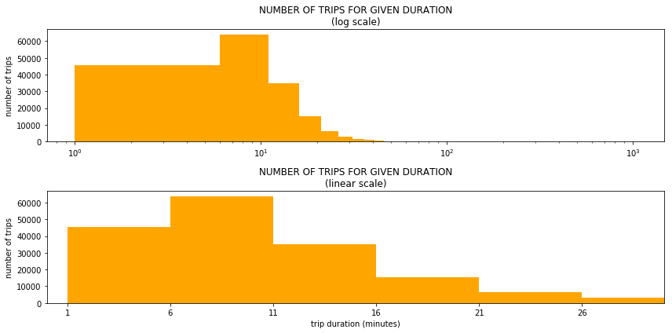

```python
# preliminary plot -
step_log = 5
plt.figure(figsize=[12,6])
plt.subplot(2,1,1)
put_labels('NUMBER OF TRIPS FOR GIVEN DURATION\n(log scale)',
           '', 'number of trips')
plt.xscale('log') # i really don't know how to scale these things.
sketch_hist('duration_min', stepsize=step_log)

# the bar chart with a limited view
step = 5
plt.subplot(2,1,2)
put_labels('NUMBER OF TRIPS FOR GIVEN DURATION\n(linear scale)',
           'trip duration (minutes)', 'number of trips')
place_ticks(duration.min(), duration.max(), step)
plt.xlim(0,30)
sketch_hist('duration_min', stepsize=step)
plt.tight_layout()
plt.show()
```

How do we explain the long tail of the plot? Either there exist superhumans capable of riding a bicycle for nearly a day, or it reflects a problem with how the service was used, or how the data was recorded. We can't discard those observations since they contain other useful information (such as user type, member gender, etc). In any case, the visuals show that most of the trip durations are around 11 minutes long.

### Univariate Plot 2: User ages

What is the age distribution of the users? Are they all mostly young, or fairly old? We can get an idea of what the plot will be like from the average user age.

```python
# what is the average user age?
member_ages = df_ford['user_age']

print("THE AVERAGE USER AGE IS {mean:.1f} YEARS.".format(mean=member_ages.mean()))
print("THE STANDARD DEVIATION IS {std:.1f} YEARS.".format(std=member_ages.std()))
```

```
THE AVERAGE USER AGE IS 34.2 YEARS.
THE STANDARD DEVIATION IS 10.0 YEARS.
```

The numbers show that most users are around 34 years old, give or take a decade. Let's choose our bin sizes so that the ages increment at steps of 4.

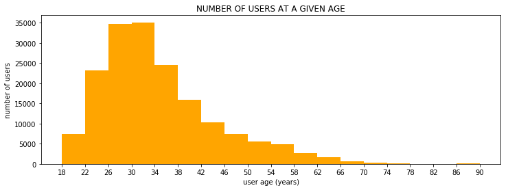

```python
# quick sketch of the customer ages
plt.figure(figsize=[12,4])
put_labels('NUMBER OF USERS AT A GIVEN AGE',
           'user age (years)', 'number of users')
sketch_hist('user_age', stepsize=4) ;

place_ticks(member_ages.min(), member_ages.max(), 4)
plt.show() ;
```

The visualisation shows broadly that a majority of the users are below 50 years of age, and a majority of those below 50 years of age are around 22 to 42 years of age, which is roughly 34 years of age give or take a decade from that.

To get a rougher overview of the age distribution, let's bin the ages into age groups and plot the counts for each age group.

```python
# to bin the ages into groups of ten items each.
# set right=False.
age_group_bins = [a for a in range(18, 10+df_ford['user_age'].max(), 10)]

# initialise with left endpoints, then append right endpoints
age_group_labels = [f'{a}' for a in age_group_bins[0:-1]]
b = [f'{a}' for a in age_group_bins[1:]] # selects the right endpoints
for i in range(len(age_group_labels)):
    age_group_labels[i] += f'-{int(b[i])-1}'

#print(age_group_bins)
#print(age_group_labels)
```

```python
# creating the age-group column
df_ford['age_group'] = pd.cut(x=df_ford['user_age'], bins=age_group_bins, labels=age_group_labels,
                              right=False)
```

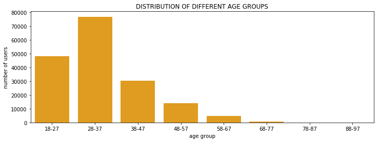

```python
# now ages are categorical
plt.figure(figsize=[12,4])

sb.countplot(data=df_ford, x='age_group', color='orange') ;
put_labels('DISTRIBUTION OF DIFFERENT AGE GROUPS',
          'age group', 'number of users')
```

From the barchart, it's clear that the users who are 28 to 37 years inclusive, are the age group with the largest counts. Next in line are the younger ones - 18 to 27 years of age.

### Univariate Plot 3: Time of day

What hour of the day do most of the users typically start their rides? What time of the day do most of the users typically end their rides? We'll answer these questions using numbers, then a visualisation.

```python
# for getting the hour of the time
def get_hours(column):
    return np.array(df_ford[column].dt.hour)
```

```python
# we'll need this specific column later
df_ford['start_hour'] = get_hours('start_time')
```

#### Start of trip

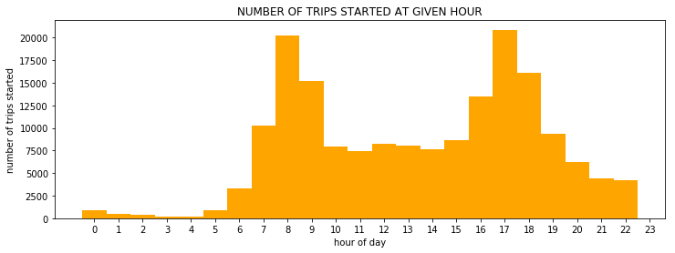

```python
# basic plot
plt.figure(figsize=(12,4))
put_labels('NUMBER OF TRIPS STARTED AT GIVEN HOUR',
           'hour of day', 'number of trips started')
# the 24 tick isn't shown because it's shifted to the right

place_ticks(least=0, most=24, step=1, offset=0.5)
sketch_hist(column='start_hour', stepsize=1) ;
```

Interestingly, we have a bimodal distribution. There are two peaks at the 8 hour and 17 hour mark (i.e. 8AM and 5PM). What could this suggest? One hypothesis is that these represent times of the day when users are heading off to work or returning from work. We'll need to explore this point further.

#### End of trip

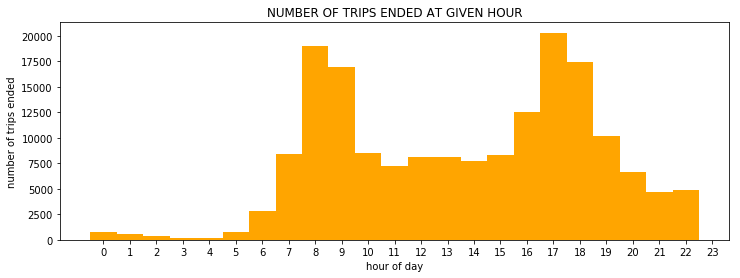

```python
# basic plot for hour at which trip ended
plt.figure(figsize=(12,4))
put_labels('NUMBER OF TRIPS ENDED AT GIVEN HOUR',
           'hour of day', 'number of trips ended')
place_ticks(least=0, most=24, step=1, offset=0.5)

sketch_hist(column=get_hours('end_time'), stepsize=1, custom_x=True)
```

The distribution is also bimodal.

For a simpler visualisation, let's group the hours into categorical 'time of day' bins. We'll bin the times in three hour increments, except for midnight to 6AM. We'll use half-intervals for each bin - including the first but excluding the last hour.

```python
# creating a part of day column
# dont forget to set right=False to get [a.b) instead of (a,b]
dpart_bins = [0]+[i for i in range(6,27,3)]
#print(dpart_bins)
dpart_labels = ('Midnight-to-Dusk','Early Morning',
                'Late Morning','Early Afternoon',
                'Late Afternoon','Early Evening','Late Evening')
#print(dpart_labels)
```

```python
# finally create the column 'part_of_day'
df_ford['part_of_day'] = pd.cut(df_ford['start_hour'], bins=dpart_bins,
                               labels=dpart_labels, right=False)
```

```python
# assess
df_ford['part_of_day'].value_counts()
```

```
Late Afternoon      42968
Early Morning       33733
Early Evening       31702
Late Morning        30621
Early Afternoon     23975
Late Evening         8564
Midnight-to-Dusk     3029
Name: part_of_day, dtype: int64
```

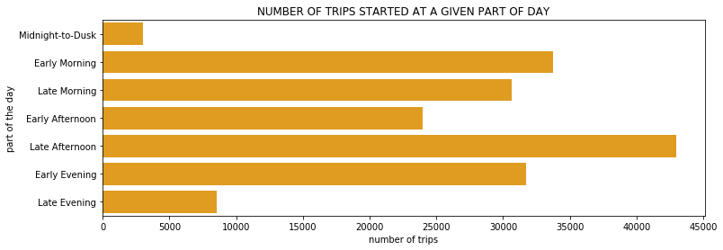

```python
# create a simple visual
daypart_counts = df_ford['part_of_day'].value_counts(ascending=True)

plt.figure(figsize=[12,4])
sb.countplot(y=df_ford['part_of_day'], color='orange') ;
plt.title('NUMBER OF TRIPS STARTED AT A GIVEN PART OF DAY')
plt.xlabel('number of trips') ;
plt.ylabel('part of the day') ;
place_ticks(least=0, most=daypart_counts.values[-1], step=5000)
```

The barplot also shows the same bimodality. We can see that most of the trips started Late Afternoon (about 3PM to 5PM). Second in place is the trips which started early in the Morning (about 6AM to 9AM).

### Univariate Plot 4: Day of week

On what day of the week do most of the trips occur?

```python
# answer the question with a name
day_counts = df_ford['weekday'].value_counts(ascending=True)
print('MOST OF THE TRIPS OCCUR ON {}.'.format(day_counts.index[-1].upper()))
```

```
MOST OF THE TRIPS OCCUR ON THURSDAY.
```

The ordering of weekdays is slightly ambiguous due to their cyclical nature. Weekdays are ordered the same way hours on a clock are ordered. What comes after Monday? Monday, over and over. Still, if we consider just one cycle we can define a useful order for the weekdays.

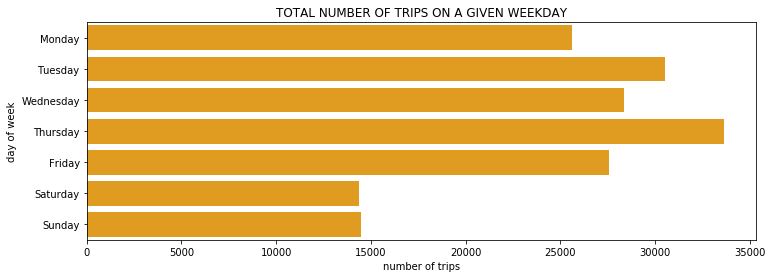

```python
# sb
#place_ticks(least=0, most=day_counts.values[0], step=4500)
plt.figure(figsize=[12,4])
sb.countplot(data=df_ford, y='weekday', color='orange') ;
put_labels('TOTAL NUMBER OF TRIPS ON A GIVEN WEEKDAY',
           'number of trips', 'day of week') ;
plt.show()
```

The trip count is also bimodal with respect to day of the week. We can see that Tuesday and Thursday boast the highest trip-taking rates. In fact if we were to remove those two, the distribution would look unimodal with a peak at Wednesday.

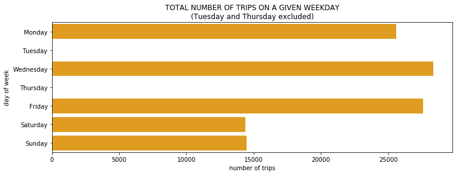

```python
# for clarity
plt.figure(figsize=[12,4])
# we defined weekday_order earlier
filtered_w = [weekday for weekday in weekday_order if weekday not in ('Tuesday','Thursday')]
data = df_ford[df_ford['weekday'].isin(filtered_w)]

sb.countplot(data=data, y='weekday', color='orange') ;
put_labels('TOTAL NUMBER OF TRIPS ON A GIVEN WEEKDAY\n(Tuesday and Thursday excluded)',
           'number of trips', 'day of week') ;
plt.show()
```

### Univariate Plot 5: Gender distribution

```python
# gender distribution pie chart
gender_counts = df_ford['user_gender'].value_counts()

# defining some useful colors
rich_orange = (0.9, 0.5, 0.1)
grayish_blue = (0.3,0.4,0.5)
grayish_gray = (0.46,0.47,0.46)
gender_colors = (rich_orange, grayish_gray, grayish_blue)
```

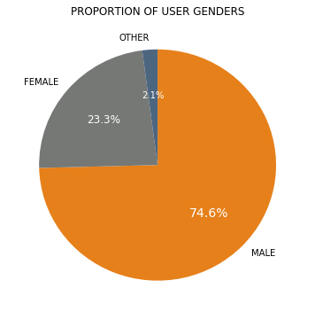

```python
# freshly-baked pie
plt.figure(figsize=(6,6))
patches, texts, autotexts = plt.pie(gender_counts.values,
                                    labels=[s.upper() for s in gender_counts.index],
                                    colors=gender_colors,
                                    startangle=90,
                                    counterclock=False,
                                    autopct='%1.1f%%') ;

# control the text attributes
for i,text in enumerate(autotexts):
    text.set_color('white')
    text.set_size(14-2*i)

plt.title('PROPORTION OF USER GENDERS')
plt.show()
```

I predicted that there'd be a balanced gender distribution but that's clearly not the case.

### Univariate Plot 6: User type

What user types are more common? We'll use a pie chart again.

```python
# subscriber type pie chart
# greenish, reddish = (0.1,0.6,0.2), (0.9,0.4,0.12)
user_counts = df_ford['user_type'].value_counts()
```

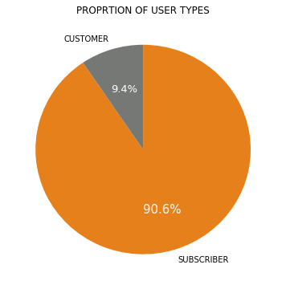

```python
# another pie.
plt.figure(figsize=(6,6))
patches, texts, autotexts = plt.pie(user_counts.values,
                                    labels=[s.upper() for s in user_counts.index],
                                    colors=(rich_orange, grayish_gray),
                                    startangle=90,
                                    counterclock=False,
                                    autopct='%1.1f%%') ;

# control the text colour
for i,text in enumerate(autotexts):
    text.set_color('white')
    text.set_size(15-2*i)

plt.title('PROPRTION OF USER TYPES')
plt.show()
# the chart shows that most of the users are subscribers
```

An overwhelming majority of the users are Subscribers rather than Customers.

### Univariate plot 7: Bike sharing data

How many enrolled in the bike-sharing option?

```python
# sharing is caring
share_counts = df_ford['bike_share_for_all'].value_counts()
```

```python
# to help customise the labels
share_counts.index
```

```
Index(['No', 'Yes'], dtype='object')
```

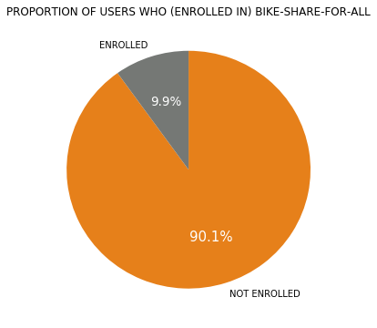

```python
# another pie.
plt.figure(figsize=(6,6))
#lbls = ['SHARED' for b in share_counts.index if b else 'NOT SHARED']
patches, texts, autotexts = plt.pie(share_counts.values,
                                    labels=['NOT ENROLLED', 'ENROLLED'],
                                    colors=(rich_orange, grayish_gray),
                                    startangle=90,
                                    counterclock=False,
                                    autopct='%1.1f%%') ;

# control the text colour
for i,text in enumerate(autotexts):
    text.set_color('white')
    text.set_size(15*((90/101)**i))

plt.title('PROPORTION OF USERS WHO (ENROLLED IN) BIKE-SHARE-FOR-ALL')
plt.show()
```

Only a small proportion of the users enrolled in the Bike-Share-for-All option.

### Univariate plot 8: Stations

Which start stations are the most frequented? How about the end stations? Because of the sheer number of stations, we will only consider a sample of them for any exploration we'll do from here on.

```python
# some useful variables
start_stations = df_ford['start_station_name']
end_stations = df_ford['end_station_name']

top10_startst = start_stations.value_counts(ascending=False).sort_values(ascending=False)[:10]
top10_endst = end_stations.value_counts(ascending=False).sort_values(ascending=False)[:10]
```

```python
# how many unique start and end stations are there?
# beware of case inconsistencies!
tempstart_lower = list(map(lambda s:s.lower(), start_stations.unique()))
tempend_lower = list(map(lambda s:s.lower(), end_stations.unique()))
```

```python
#
uniques_lower = []
for stations_list in (tempstart_lower, tempend_lower):
    seen = []
    for station in stations_list:
        if station not in seen:
            seen.append(station)
    uniques_lower.append(seen)

unique_starts = uniques_lower[0]
unique_ends = uniques_lower[1]
```

```python
# how many are there?
print(f'THERE ARE {len(unique_starts)} UNIQUE START STATIONS.')
print(F'THERE ARE {len(unique_ends)} UNIQUE END STATIONS.')
```

```
THERE ARE 329 UNIQUE START STATIONS.
THERE ARE 329 UNIQUE END STATIONS.
```

```python
# top 10 start stations in decreasing order of frequency
print(75*'_', '\n', 'TOP 10 START STATIONS', 40*' ',
      'FREQUENCY', '\n', 75*'_', sep='')
print(top10_startst)
print(75*'_', '\n', 'TOP 10 END STATIONS', 40*' ',
      'FREQUENCY', '\n', 75*'_', sep='')
print(top10_endst)
```

```
___________________________________________________________________________
TOP 10 START STATIONS                                        FREQUENCY
___________________________________________________________________________
Market St at 10th St                                         3645
San Francisco Caltrain Station 2  (Townsend St at 4th St)    3403
Berry St at 4th St                                           2949
Montgomery St BART Station (Market St at 2nd St)             2702
Powell St BART Station (Market St at 4th St)                 2614
San Francisco Caltrain (Townsend St at 4th St)               2571
San Francisco Ferry Building (Harry Bridges Plaza)           2536
Howard St at Beale St                                        2216
Steuart St at Market St                                      2189
Powell St BART Station (Market St at 5th St)                 2140
Name: start_station_name, dtype: int64
___________________________________________________________________________
TOP 10 END STATIONS                                        FREQUENCY
___________________________________________________________________________
San Francisco Caltrain Station 2  (Townsend St at 4th St)    4618
Market St at 10th St                                         3700
Montgomery St BART Station (Market St at 2nd St)             3456
San Francisco Ferry Building (Harry Bridges Plaza)           3146
San Francisco Caltrain (Townsend St at 4th St)               2860
Powell St BART Station (Market St at 4th St)                 2853
Berry St at 4th St                                           2781
The Embarcadero at Sansome St                                2334
Steuart St at Market St                                      2263
Powell St BART Station (Market St at 5th St)                 2150
Name: end_station_name, dtype: int64
```

```python
# how many top ten starts are also top ten stops?
temp = [st.lower() for st in top10_endst.index] # in case of case inconsistencies
dual_top10 = [station for station in top10_startst.index if station.lower() in temp] # intersection
if len(dual_top10)==0:
    print("THE TOP 10 START STATIONS AND TOP 10 END STATIONS ARE MUTUALLY EXCLUSIVE")
else:
    #print(len(dual_top10))
    for i,st in enumerate(dual_top10):
        print(i+1, st)
```

```
1 Market St at 10th St
2 San Francisco Caltrain Station 2  (Townsend St at 4th St)
3 Berry St at 4th St
4 Montgomery St BART Station (Market St at 2nd St)
5 Powell St BART Station (Market St at 4th St)
6 San Francisco Caltrain (Townsend St at 4th St)
7 San Francisco Ferry Building (Harry Bridges Plaza)
8 Steuart St at Market St
9 Powell St BART Station (Market St at 5th St)
```

So it seems there are nine stations which function as both top 10 start and top 10 end stations.

#### Start Stations

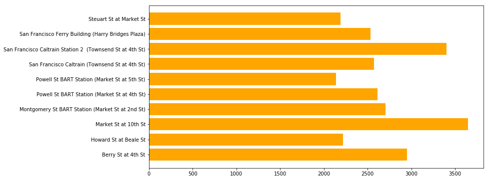

```python
# plot the start stations using barh?
plt.figure(figsize=[12,6])
plt.barh(top10_startst.index, top10_startst.values, color='orange') ;
```

"Market St at 10th St" seems to be a rather popular start station.

#### End stations

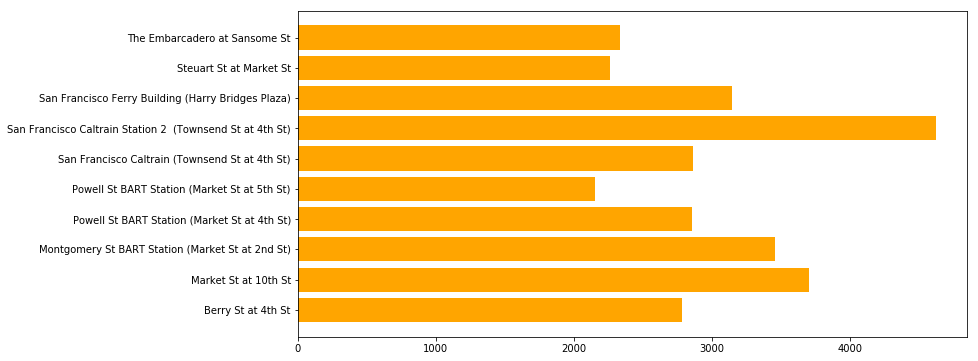

```python
# end
plt.figure(figsize=[12,6])
plt.barh(top10_endst.index, top10_endst.values, color='orange') ;
```

"San Francisco Caltrain Station 2 (Townsend St at 4th St)" seems to be a fairly popular end station.

### Discuss the distribution(s) of your variable(s) of interest. Were there any unusual points? Did you need to perform any transformations?

> There were a few unusually large trip durations. Some lasted for nearly 24 hours. Unless some of the users had superhuman levels of endurance, these are likely mistakes from the data recording process.

> Both the start hour and weekday followed bimodal distributions. Early Morning and Late Afternoon boasted the highest number of trips, and Tuesday and Thursday boasted the highest number of trips compared to the other start times and days respectively.

> The gender distribution was not what I naively expected. it mostly skewed male. I can't think of any factors that could've caused this (not any factors present in the data) so I won't explore that too much.

### Of the features you investigated, were there any unusual distributions? Did you perform any operations on the data to tidy, adjust, or change the form of the data? If so, why did you do this?

> I decided to create categorical (but ordinal) bins from the age and start time data. The only reason is that it felt natural, and made for impler visualisations. Although the data had trips with unusually long durations, I did not remove them because I felt they contained useful information not related to trip durationand that it was a point worth exploring. I instead changed the x-scaling of the histogram and made it logarithmic.

## Bivariate Exploration

Now that we've gotten a broad overview of our variables, we'll examine the following relationships:

- subscription type and trip duration (relative)
- bike_shared and user_type (the counts are the z-axis)
- time started and time ended (categorical vs categorical)
- start hour and weekday. Compare weekdays versus weekends. Is it still bimodal?
- gender and station location (categorical vs categorical - gender is independent)
- gender and time started (categorical vs categorical-ordinal. Gender is independent)
- station location and time started (categorical-nominal vs categorical-ordinal. Station loc is independent)

But first let's get a broad overview of the relationships using a facet grid.

To make our bivariate explorations far more convenient, we'll define two useful functions. The first retrieves categorical-categorical distributions, the second describes the distribution in words.

```python
# get the proportional distribution of dependent categorical variable, for a specific independent categorical var
# intended for categorical-categorical exploration.

def get_categorical_props(indep, specific_indep, dep, data=df_ford): # get proportions
    # filters the data frame. Not the most elegant, but it's all i can do for now
    df = data[data[indep]==specific_indep]
    df_indep_counts = df[dep].value_counts(ascending=True)
    n_users = sum(df_indep_counts.values)

    prop_dict = dict(zip(df_indep_counts.index, df_indep_counts.values))
    # convert to proportions
    for dependent_type in df_indep_counts.index:
        prop_dict[dependent_type] = int(10000*prop_dict[dependent_type]/n_users)/100
    return prop_dict
```

```python
# sometimes we need numbers
def props_in_words(indep, dep, data=df_ford, lb='-'):
    # lb means line break
    indep_values = data[indep].unique()
    for indep_value in indep_values:
        cat_props = get_categorical_props(indep, indep_value, dep, data)
        for dep_value, percent in cat_props.items():
            print(f'{percent} percent of {indep_value} match {dep_value}')
        print(50*lb)
```

```python
# some useful dataframe samples, constants
df_timelimited = df_ford[df_ford['duration_min']<=60]
df_time_excess = df_ford[df_ford['duration_min']>60]
df_sampled = df_ford.sample(500, random_state=30)

numeric_vars = ['user_age', 'duration_min', 'start_hour']
categoric_vars = ['age_group', 'part_of_day', 'weekday',
                  'user_gender', 'part_of_day', 'bike_shared', 'user_type']
```

### Broad overview

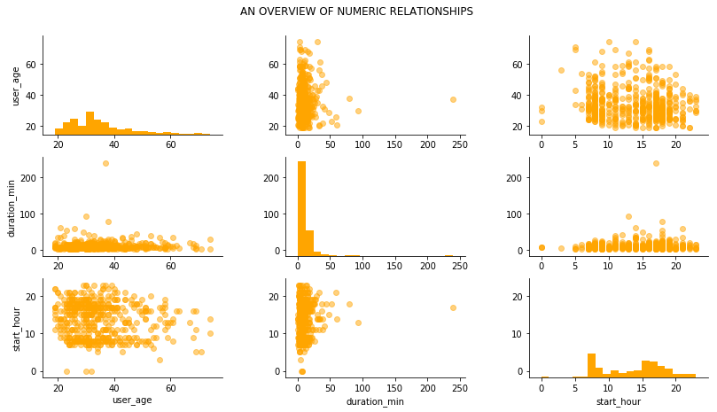

```python
# broad overview of the few numeric variables
pgrid = sb.PairGrid(data=df_ford.sample(500), vars=numeric_vars) ;
pgrid.map_diag(plt.hist, bins=20, color='orange') ;
pgrid.map_offdiag(plt.scatter, alpha=0.5, color='orange') ;
pgrid.fig.set_size_inches(12,6)
plt.suptitle('AN OVERVIEW OF NUMERIC RELATIONSHIPS', x=0.5, y=1.05) ;
```

The diagonal histograms are merely univariate frequency counts, which we've already explored. Off the diagonal, we have a broad overview of the bivariate relationships. We can see that...

- The users responsible for the longest trip durations seem to be younger.
- Most of the users who start their trips very early or late in the day are relatively yonug.

### Bivariate Exploration 1: Age

We'll compare age against some of the other categoric and numeric variables. Age is treated as an independent variable which influences the others somehow, or at least appears to influence them.

#### 1A: Age and trip duration

Naively, we'd expect the younger users to have longer trip durations and the older users to have shorter trip durations. But what will the data reveal?

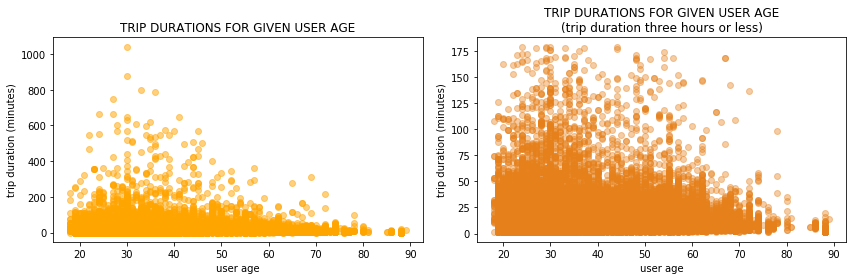

```python
# scatterplot for trip duration
plt.figure(figsize=[12,4])

plt.subplot(1,2,1)
put_labels('TRIP DURATIONS FOR GIVEN USER AGE','user age', 'trip duration (minutes)')
plt.scatter(data=df_ford, x='user_age', y='duration_min', alpha=0.5, color='orange') ;

plt.subplot(1,2,2)
put_labels('TRIP DURATIONS FOR GIVEN USER AGE\n(trip duration three hours or less)',
           'user age', 'trip duration (minutes)')
plt.scatter(data=df_ford[df_ford['duration_min']<=180],
            x='user_age', y='duration_min', alpha=0.4, color=rich_orange)

plt.tight_layout()
plt.show()
```

For both plots, the density of the dots shows that most of the trips fal below the 200 minute mark. However, it seems that the longest trips mostly come from the younger members (less than 50 years of age).

The scatterplot on the right gives a closer view of the distribution of those trips, and visually confirms that most of the longer trips are due to the younger members. Next, let's try to get a sense of the average trip duration for each member age.

```python
# average trip duration per member age - create the data we need
grouped_age = df_ford.groupby('user_age')
grouped_age_avgdur = grouped_age['duration_min'].mean()
grouped_age_avgdur.head()
```

```
user_age
18    40.852941
19    12.820420
20    10.744205
21    10.587188
22    10.501585
Name: duration_min, dtype: float64
```

Now for the visualisation.

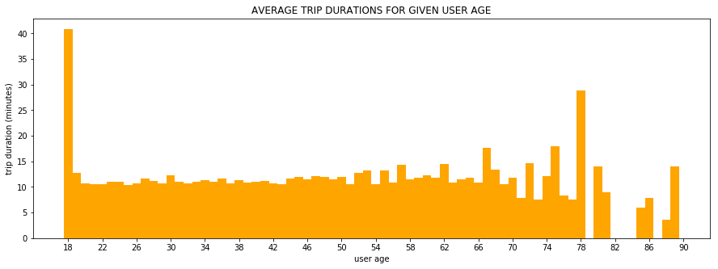

```python
# plotting the average trip duration for given user age
plt.figure(figsize=[15,5])
put_labels('AVERAGE TRIP DURATIONS FOR GIVEN USER AGE',
          'user age', 'trip duration (minutes)')
plt.bar(grouped_age_avgdur.index, grouped_age_avgdur.values, color='orange', width=1) ;
place_ticks(least=grouped_age_avgdur.index[0], most=grouped_age_avgdur.index[-1],
           step=4)
```

The shape of the curve is interesting. It follows a saddle-like pattern with the highest average trip duration coming from exactly the 18-year-old age group. The trip duration is roughly level after that, but roughly increases slightly and peaks again for the users who were 78 years of age. Next we'll show a simpler plot which uses age groups rather than exact ages.

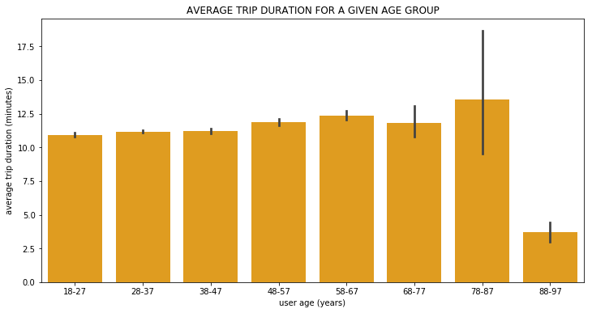

```python
# average trip duration per member age - plot the plot.
plt.figure(figsize=[12,6])
sb.barplot(data=df_ford, x='age_group', y='duration_min', color='orange')
put_labels('AVERAGE TRIP DURATION FOR A GIVEN AGE GROUP',
          'user age (years)', 'average trip duration (minutes)')
plt.show()
```

The distribution looks different, with the older members boasting the longest average trip durations and greater variability. One way to explain this is that users in those bins are relatively few in number, so their trip duration statistics are more influenced by outliers.

#### 1B: Age and Part-of-day

For a given age group, how many users started at a given part of the day? Recall that parts of the day are just binned start hours. Because a trip must start for it to end, and because most of the trip durations were fairly short we'll only look at the part of the day for which the trips started.

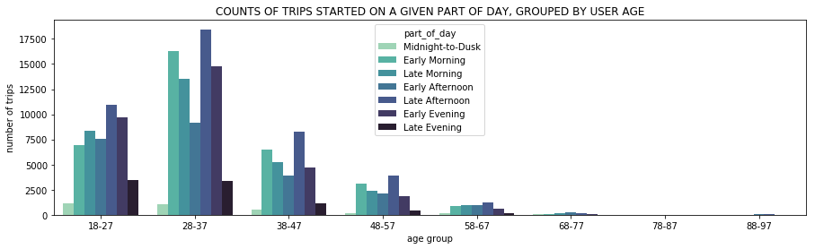

```python
# what part of the day had the highest count of trips started? Find out for each age group.
plt.figure(figsize=[15,4]) ;
sb.countplot(data=df_ford, x='age_group', hue='part_of_day', palette='mako_r') ;
put_labels('COUNTS OF TRIPS STARTED ON A GIVEN PART OF DAY, GROUPED BY USER AGE',
          'age group', 'number of trips')
```

Most of these are bimodal, except for the older users. In industrialised countries (or the US at least), the working age is around 20 to 50 or so years of age, give or take a decade. The distributions are consistent with the claim that the bimodality of start time is due to users going to work or leaving work. Note that for those age groups, the peaks occur at roughly the same times of the day.

Because of logistic difficulties plotting relative grouped bar charts (in matplotlib or seaborn for that matter), let's try manually plotting the relative frequencies for each of the smaller bars.

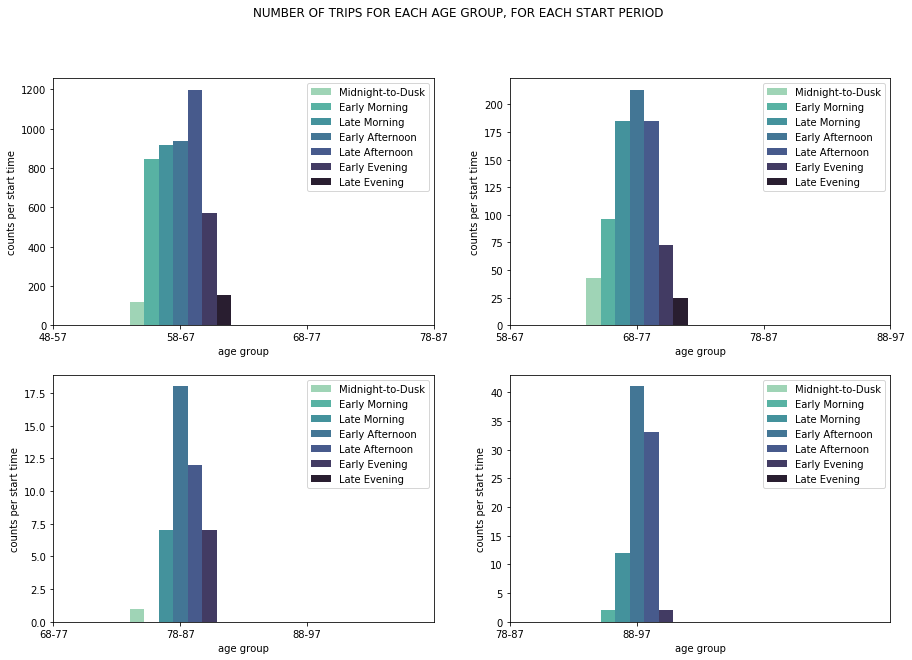

```python
# plotting the rest manually - part of day
rows, columns = 2,2
count = 1
short_agebars = ('58-67','68-77','78-87','88-97')
viewlimit = 3

plt.suptitle('NUMBER OF TRIPS FOR EACH AGE GROUP, FOR EACH START PERIOD')
for i in range(1,rows*columns+1):
    plt.subplot(2,2,i).figure.set_size_inches(15,10)
    subframe = df_ford[df_ford['age_group']==short_agebars[i-1]]
    #print(subframe.age_group.unique()) for debugging
    ax = sb.countplot(data=subframe, x='age_group', hue='part_of_day', palette='mako_r') ;
    ax.set(xlabel='age group', ylabel='counts per start time', xlim=[viewlimit,viewlimit+3])
    viewlimit += 1
    plt.legend(loc='upper right')

plt.show()
```

Just as we expected, the bimodality disappears for the older users.

#### 1C: Age and Weekday

How many people in a certain age group had a trip on a certain weekday? Let's recall that a vast majority of the trips started and ended on the same weekday, so we don't need to make a distinction between start time and end time.

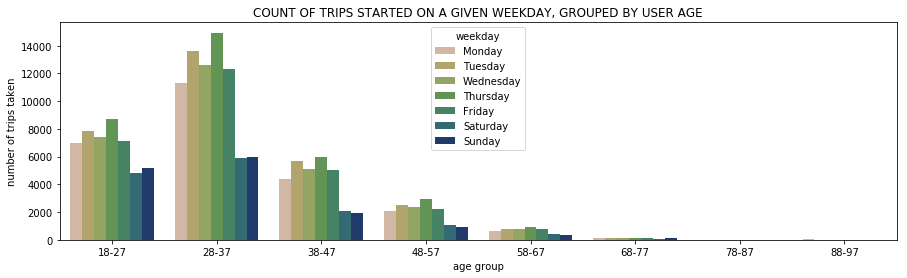

```python
# for a given age group, what day boasts the highest counts of trips taken?
plt.figure(figsize=[15,4]) ;
sb.countplot(data=df_ford, x='age_group', hue='weekday', palette='gist_earth_r') ;
put_labels('COUNT OF TRIPS STARTED ON A GIVEN WEEKDAY, GROUPED BY USER AGE',
          'age group', 'number of trips taken')
```

Let's plot each of the smaller bars separately so we get a sense of the relative proportions.

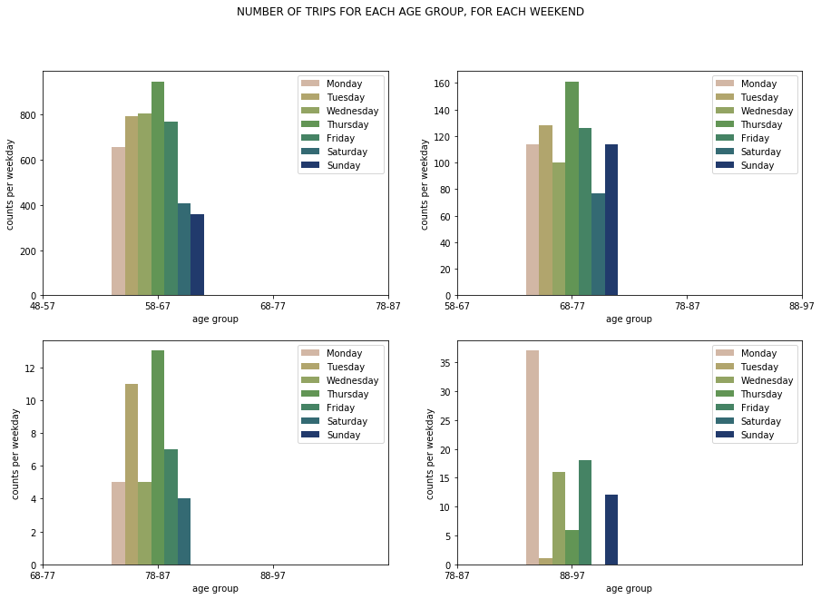

```python
# plotting the rest manually
rows, columns = 2,2
count = 1
short_agebars = ('58-67','68-77','78-87','88-97')
viewlimit = 3

plt.suptitle('NUMBER OF TRIPS FOR EACH AGE GROUP, FOR EACH WEEKEND')
for i in range(1,rows*columns+1):
    plt.subplot(2,2,i).figure.set_size_inches(15,10)
    subframe = df_ford[df_ford['age_group']==short_agebars[i-1]]
    #print(subframe.age_group.unique()) for debugging
    ax = sb.countplot(data=subframe, x='age_group', hue='weekday', palette='gist_earth_r') ;
    ax.set(xlabel='age group', ylabel='counts per weekday', xlim=[viewlimit,viewlimit+3])
    viewlimit += 1
    plt.legend(loc='upper right')

plt.show()
```

#### 1D: Age and User Types

How does age correlate with the user type of a given user?

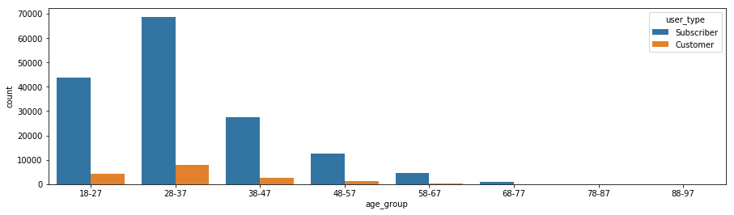

```python
# age and user type
plt.figure(figsize=[15,4]) ;
sb.countplot(data=df_ford, x='age_group', hue='user_type') ;
```

It seems consistently that most of the users were Subscribers regardless of age group.

```python
# in words
props_in_words('age_group','user_type')
```

```
8.87 percent of 38-47 match Customer
91.12 percent of 38-47 match Subscriber
--------------------------------------------------
10.27 percent of 28-37 match Customer
89.72 percent of 28-37 match Subscriber
--------------------------------------------------
9.0 percent of 18-27 match Customer
90.99 percent of 18-27 match Subscriber
--------------------------------------------------
9.08 percent of 48-57 match Customer
90.91 percent of 48-57 match Subscriber
--------------------------------------------------
6.37 percent of 58-67 match Customer
93.62 percent of 58-67 match Subscriber
--------------------------------------------------
3.53 percent of 68-77 match Customer
96.46 percent of 68-77 match Subscriber
--------------------------------------------------
13.33 percent of 78-87 match Customer
86.66 percent of 78-87 match Subscriber
--------------------------------------------------
1.11 percent of 88-97 match Customer
98.88 percent of 88-97 match Subscriber
--------------------------------------------------
```

#### 1E: Age and Bike-Share-For-All

How does age correlate with Bike-Share status?

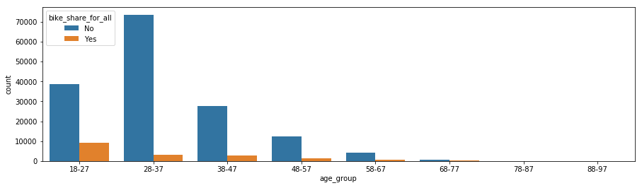

```python
# age and bike-share
plt.figure(figsize=[15,4]) ;
sb.countplot(data=df_ford, x='age_group', hue='bike_share_for_all') ;
```

```python
props_in_words('age_group','bike_share_for_all')
```

```
8.77 percent of 38-47 match Yes
91.22 percent of 38-47 match No
--------------------------------------------------
3.97 percent of 28-37 match Yes
96.02 percent of 28-37 match No
--------------------------------------------------
19.43 percent of 18-27 match Yes
80.56 percent of 18-27 match No
--------------------------------------------------
10.36 percent of 48-57 match Yes
89.63 percent of 48-57 match No
--------------------------------------------------
12.25 percent of 58-67 match Yes
87.74 percent of 58-67 match No
--------------------------------------------------
22.31 percent of 68-77 match Yes
77.68 percent of 68-77 match No
--------------------------------------------------
40.0 percent of 78-87 match No
60.0 percent of 78-87 match Yes
--------------------------------------------------
100.0 percent of 88-97 match No
--------------------------------------------------
```

### Bivariate Plot 2: User type

We'll treat user type as an 'independent' variable which influences (or correlates with) trip duration and bike-sharing tendency.

#### 2A: User Type and Trip duration

What is the average trip duration for each user type?

[figure not shown]

```python
# put a violin plot
colors = sb.color_palette()

plt.figure(figsize=[10,9])
plt.subplot(2,2,1)
sb.violinplot(data=df_timelimited,
              x='user_type', y='duration_min', color=colors[1], inner='quartile') ;
put_labels('TRIP DURATION FOR A GIVEN USER TYPE\n(Duration 60 minutes or less)',
          'user type', 'trip duration (minutes)')

plt.subplot(2,2,2)
sb.violinplot(data=df_time_excess,
              x='user_type', y='duration_min', color=colors[1], inner='quartile') ;
put_labels('TRIP DURATION FOR A GIVEN USER TYPE\n(Duration more than 60 minutes)',
          'user type', 'trip duration (minutes)')

# log scale of overall dataframe
plt.subplot(2,2,3)
plt.yscale('log')
sb.violinplot(data=df_time_excess, x='user_type', y='duration_min', color=colors[1], inner='quartile') ;
put_labels('TRIP DURATION FOR A GIVEN USER TYPE\n(All durations, y-axis is log scale)',
          'user type', 'trip duration (minutes)')

plt.tight_layout()
```

We can see from the above violin plots that on average, customers had a slightly but noticeably longer trip duration than the subscribers. It's also important to note the 'spread' of the distributions (from the width of the violinplots). The top-left plot shows us that for trip durations less than 60 minutes, the trip durations are more tightly clustered around the shorter trip length. In other words, a lot of subscribers consistently had shorter trip lengths. In contrast, customers had more variability with respect to their trip length, at least for durations that were 60 minutes or less.

Let's see this with the box plots.

[figure not shown]

```python
# the boxplot
plt.figure(figsize=[10,9])
plt.subplot(2,2,1)
sb.boxplot(data=df_timelimited,
              x='user_type', y='duration_min', color=colors[1]) ;
put_labels('TRIP DURATION FOR A GIVEN USER TYPE\n(Duration 60 minutes or less)',
          'user type', 'trip duration (minutes)')

plt.subplot(2,2,2)
sb.boxplot(data=df_time_excess,
              x='user_type', y='duration_min', color=colors[1]) ;
put_labels('TRIP DURATION FOR A GIVEN USER TYPE\n(Duration more than 60 minutes)',
          'user type', 'trip duration (minutes)')

# log scale of overall dataframe
plt.subplot(2,2,3)
plt.yscale('log')
sb.boxplot(data=df_time_excess, x='user_type', y='duration_min', color=colors[1]) ;
put_labels('TRIP DURATION FOR A GIVEN USER TYPE\n(All durations, y-axis is log scale)',
          'user type', 'trip duration (minutes)')

plt.tight_layout()
```

#### 2B: User type and Bike-sharing

We'll use a grouped bar chart to count.

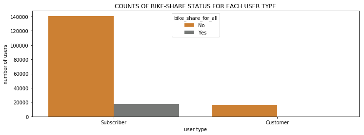

```python
# user type against bike shared
plt.figure(figsize=[12,4])
sb.countplot(data=df_ford, x='user_type', hue='bike_share_for_all', palette=(rich_orange, grayish_gray)) ;
put_labels('COUNTS OF BIKE-SHARE STATUS FOR EACH USER TYPE',
          'user type', 'number of users')
```

We don't need to look at relative proportions. It's obvious that almost no Customers enrolled in the Bike-Share program. To be sure, let's hear what the narrator has to say...

```python
#
props_in_words('user_type','bike_share_for_all')
```

```
10.93 percent of Subscriber match Yes
89.06 percent of Subscriber match No
--------------------------------------------------
100.0 percent of Customer match No
--------------------------------------------------
```

### Bivariate Plot 3: Start hour

#### 3A: Start hour and End hour

In the Univariate Exploration part we saw that the start and end hours had a bimodal distribution with respect to the counts. In other words, there were two times of the day for which many (though not necessarily most) of the trips either started or ended. The trip-taking rate was steady then suddenly spiked and dropped around 7 to 8 AM, and 4 to 5 PM. One possible explanation is that for 7-8 AM, most of the users wanted to get to work. For 4-5 PM, most of the users wanted to leave work for somewhere else. Considering that many users were around working age (25 to 45 years old), it's a feasible explanation though further data would be needed.

However, if we plot both the start and end hours side-by-side, we notice that their shapes are roughly similar, with small differences in height. Why is this?

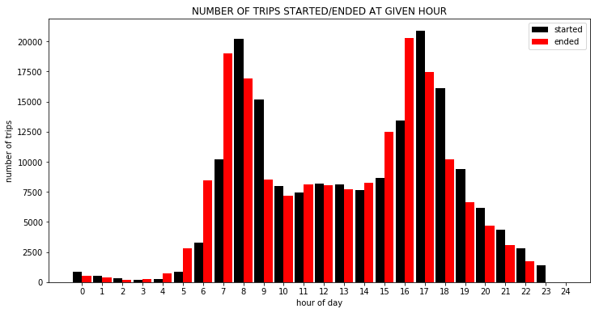

```python
# start and end time together
plt.figure(figsize=(12,6))
put_labels('NUMBER OF TRIPS STARTED/ENDED AT GIVEN HOUR',
           'hour of day', 'number of trips')
place_ticks(least=0, most=24, step=1, offset=0.45)

# we need more control so we can't use sketch_hist
bins = np.arange(0, 24+1, 1)
plt.hist(x=get_hours('start_time'), bins=bins, label='started', width=0.45, color='black') ;
plt.hist(x=get_hours('end_time'), bins=bins+0.45, label='ended', width=0.45, color='red') ;
plt.legend() ;
```

#### One possible explanation

The reason for the similarity in shape is that most of the trip durations were fairly short.

It may seem obvious that the start and end hour plots should have the same shape, but that's not necessarily guaranteed. We can imagine a different Bike-sharing program with poor logistics which only has one (or sufficiently few) end stations, and all those end stations open and close during a very small window of the day.

All else being equal (e.g start stations being available, people starting trips at the same time), the poor logistics of the end stations would force all trips to end within the same narrow window of time on any given day. In that case, the modality of the end hours would look unimodal because no matter when the users started, they could only end their trips around a specific time of day.

However, this Bike-sharing program doesn't seem to be like that. Most users could end their trips shortly after they started, and considering the broad geographical distribution of the Bike-sharing program this could indicate good logistics. But what could explain the differences in height?

#### Explaining the differences in height

Let's make a few assumptions. First, we assume that a vast majority of the users ended their trip at most one hour after they started. This is justified from the average trip duration. What this means for the visualisation is that the height of the ending bars is due to...

- Users who started in the previous hour (e.g started by 10:00 AM and ended by 11:00 AM, or started by 10:50 AM and ended by 11:10 AM)
- Users who started in the same hour (e.g. started by 10:30 AM and ended by 10:40 AM)

For a given hour, there are two possible cases, keeping in mind that the average trip duration is fairly short (about 11 minutes). Let's say it's an hour at best.

- The start bar is taller than the end bar. There are two feasible explanations for this.
  - The first explanation for this is that a number of the users started *late* within the current hour and (after a short trip) ended early within the next hour. For example, 10:54 AM to 11:04 AM is just a ten-minute trip but it crosses an hour boundary.
  - The second is that a number of the users started early within the current hour (e.g. 10:00 AM) and after a long trip duration (say, 50 minutes) they ended within the next hour (e.g. 10:10 AM to 11:00 AM).
- The start bar is shorter than the end bar.
  - Considering the above case, the greater height of the end bar comes from people who started in the previous hour, as well as some people who started within the same hour.

If the above explanations are correct, the key insight is as follows - **The similarity of the distributions reinforces the fact that most of the trip durations were fairly short**, and could be ended conveniently.

#### 3B: Start hour and trip duration

Is there any correlation between the start hour and the average trip duration?

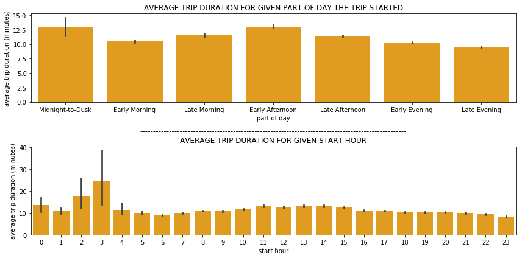

```python
# a plot showing average trip duration for time started
plt.figure(figsize=[12,6])

plt.subplot(2,1,1)
sb.barplot(data=df_ford, x='part_of_day', y='duration_min', color='orange') ;
put_labels('AVERAGE TRIP DURATION FOR GIVEN PART OF DAY THE TRIP STARTED',
          'part of day', 'average trip duration (minutes)')

# more detail
plt.subplot(2,1,2)
sb.barplot(data=df_ford, x='start_hour', y='duration_min', color='orange')
put_labels(100*'-'+'\nAVERAGE TRIP DURATION FOR GIVEN START HOUR',
          'start hour', 'average trip duration (minutes)')

plt.tight_layout()
plt.show()
```

The first (topmost) plot shows us that the largest trip durations come from trips started around Midnight-to-Dusk (which is 12AM midnight to just before 6AM in the morning). The second barplot shows us greater detail. We can see that it's specifically trips which started at 3AM that account for the highest average trip durations.

Let's briefly explore start hour and trip duration, with the duration split at the 60 minute mark.

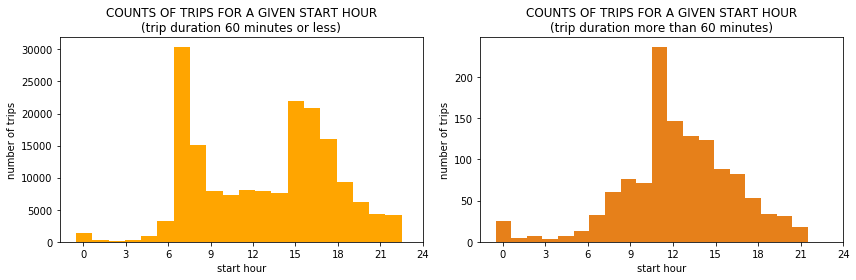

```python
# start hour and trip duration
plt.figure(figsize=[12,4])

plt.subplot(1,2,1)
put_labels('COUNTS OF TRIPS FOR A GIVEN START HOUR\n(trip duration 60 minutes or less)',
          'start hour', 'number of trips')
plt.hist(data=df_timelimited, x='start_hour', bins=20, color='orange')
place_ticks(least=0, most=24, step=3, offset=0.5)

plt.subplot(1,2,2)
put_labels('COUNTS OF TRIPS FOR A GIVEN START HOUR\n(trip duration more than 60 minutes)',
          'start hour', 'number of trips')
plt.hist(data=df_time_excess, x='start_hour', bins=20, color=rich_orange)
place_ticks(least=0, most=24, step=3, offset=0.5)

plt.tight_layout()
```

What this shows is that for the longer trip durations, there is no bimodality with regards to start hour. The hour with the highest trip-taking rate is around 11AM-12PM. This gives us further insight regarding the excessively long trip durations.

### Bivariate Plot 4: Weekday

How does weekday influence other select variables of choice?

#### 4A: Weekday and Start time

This will be a useful bivariate exploration. One hypothesis that's been floating around is that the bimodality of the start times is due to most of the customers rushing to work in the morning and rushing from work in the late afternoon. There's no solid proof of this, but considering that not many people in industrialised countries work on weekends (as of 2019), if we observe that the bimodality drops on weekends then that could count as evidence for our hypothesis.

Here, weekday is treated as an independent variable which 'influences' the start time somehow.

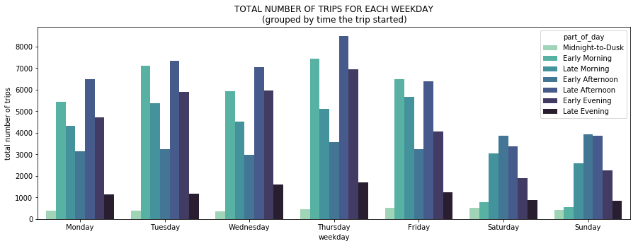

```python
#
plt.figure(figsize=[15,5])
sb.countplot(data=df_ford, x='weekday', hue='part_of_day', palette='mako_r') ;
put_labels('TOTAL NUMBER OF TRIPS FOR EACH WEEKDAY\n(grouped by time the trip started)',
          'weekday', 'total number of trips')
```

Interestingly, the distribution becomes unimodal for Saturday and Sunday, just as we described. This isn't the most scientific approach, but it strongly suggests that the hypothesis is correct.

#### 4B: Weekday and Trip duration

What is the average trip duration for each weekday?

[figure not shown]

```python
# barplot
plt.figure(figsize=[12,4])
put_labels('AVERAGE TRIP DURATION FOR EACH WEEKDAY',
          'trip duration','weekday')
sb.barplot(data=df_ford, x='duration_min', y='weekday', color='orange')
plt.xlabel('mean trip duration')
place_ticks(least=0,most=16,step=2)
```

We can see that the weekends have the highest average trip durations.

### Bivariate Plot 5: Gender

Gender is another plausible independent variable. How does it correlate with trip duration? How does it correlate with start time? How does it correlate with subscription type or Bike-Share status?

#### 5A: Gender and Average trip duration

Is there any significant correlation between gender and average trip duration?

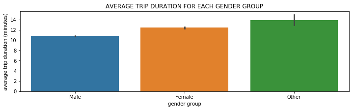

```python
# average trip duration against gender
plt.figure(figsize=[12,3])
sb.barplot(data=df_ford, x='user_gender', y='duration_min') ;
put_labels('AVERAGE TRIP DURATION FOR EACH GENDER GROUP',
          'gender group', 'average trip duration (minutes)')
```

It seems the users with non-specific gender accounted for the longest trip durations.

#### 5B: Gender and Start time

'Average start time' won't be too meaningful, so we'll have to use a clustered bar chart.

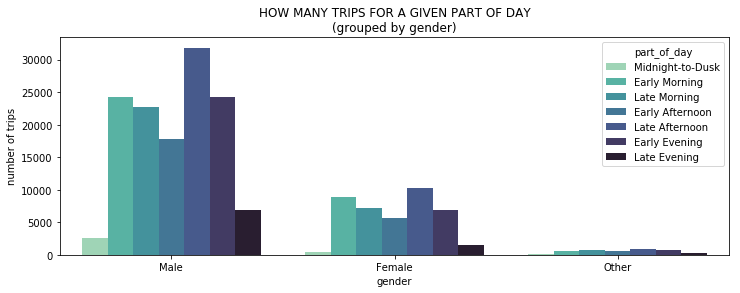

```python
# average start time for each gender group
plt.figure(figsize=[12,4]) ;
sb.countplot(data=df_ford, x='user_gender', hue='part_of_day', palette='mako_r') ;
put_labels('HOW MANY TRIPS FOR A GIVEN PART OF DAY\n(grouped by gender)',
          'gender', 'number of trips')
```

What's important is the shape of the curves for each gender group. For male and female users, the trend is roughly the same. The only difference is for the users with unspecified gender.

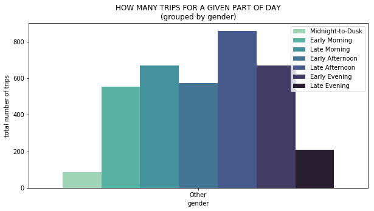

```python
# plotting the last manually
viewlimit = 3
plt.figure(figsize=[10,5])
subframe = df_ford[df_ford['user_gender']=='Other']
ax = sb.countplot(data=subframe, x='user_gender', hue='part_of_day', palette='mako_r')
ax.set(xlabel='gender', ylabel='total number of trips',
       title='HOW MANY TRIPS FOR A GIVEN PART OF DAY\n(grouped by gender)')
plt.legend(loc='upper right')

plt.show()
```

The distribution is roughly the same. It follows an 'M' shape. What this means is that regardless of gender, users had a tendency to start their trips at roughly the same parts of the day.

#### 5C: Gender and User type

We're treating gender as an independent variable. We want to know for each gender, the proportion of subscribers to customers.

```python
# get the data for the visuals
g_props_m = get_categorical_props('user_gender','Male','user_type')
g_props_f = get_categorical_props('user_gender','Female','user_type')
g_props_o = get_categorical_props('user_gender','Other','user_type')
```

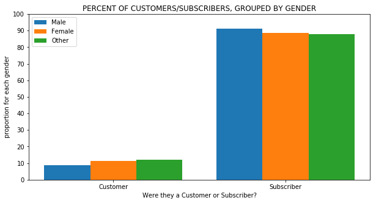

```python
# tediously plot the proportional grouped bars manually
# matplotlib or seaborn don't make it easy to plot relative grouped bar charts
w_scale = 4/5
width = 1/3
tick_dummies_m = np.array([i for i in range(len(g_props_m.keys()))]) # just placeholders for the proper labels
bars_m = [percent for percent in g_props_m.values()]
tick_dummies_f = tick_dummies_m + w_scale*width
bars_f = [percent for percent in g_props_f.values()]
tick_dummies_o = tick_dummies_m + w_scale*2*width
bars_o = [percent for percent in g_props_o.values()]

plt.figure(figsize=[10,5])
plt.bar(tick_dummies_m, bars_m, width=w_scale*width, label='Male')
plt.bar(tick_dummies_f, bars_f, width=w_scale*width, label='Female')
plt.bar(tick_dummies_o, bars_o, width=w_scale*width, label='Other')

plt.xticks(np.arange(0,1+1,1)+w_scale*width, g_props_m.keys())
place_ticks(least=0, most=100, step=10, axis='y')
put_labels('PERCENT OF CUSTOMERS/SUBSCRIBERS, GROUPED BY GENDER',
          'Were they a Customer or Subscriber?', 'proportion for each gender')
plt.legend()
plt.show()
```

What we want to look at is the height differences between groups of (differently-coloured) bars. Note that for Customers, the height increases slightly but noticeably. For Subscribers, the height decreases also slightly but noticeably. What this means is that people in the different gender groups had (slightly) different likelihoods of being Customers or Subscribers. Male users had the least chance of being Customers, but the most chance of being Subscribers.

Users with unspecified gender had the most chance of being Customers, but the least chance of being Subscribers. Female users were stuck in-between in either case. The differences are slight, but they're noticeable. To corroborate this, let's ask for the proportions in words...

```python
# tell us
props_in_words('user_gender','user_type')
```

```
8.78 percent of Male match Customer
91.21 percent of Male match Subscriber
--------------------------------------------------
11.3 percent of Female match Customer
88.69 percent of Female match Subscriber
--------------------------------------------------
12.22 percent of Other match Customer
87.77 percent of Other match Subscriber
--------------------------------------------------
```

#### 5D: Gender and Bike-Share

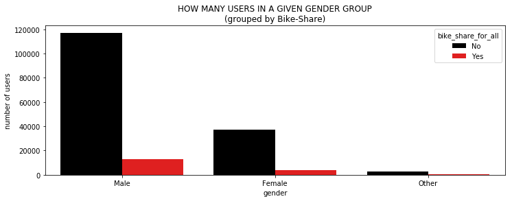

```python
# gender and bike_share
plt.figure(figsize=[12,4])
sb.countplot(data=df_ford, x='user_gender', hue='bike_share_for_all', palette=('black', 'red')) ;
put_labels('HOW MANY USERS IN A GIVEN GENDER GROUP\n(grouped by Bike-Share)',
           'gender','number of users')
```

```python
# in words...
props_in_words('user_gender','bike_share_for_all')
```

```
10.02 percent of Male match Yes
89.97 percent of Male match No
--------------------------------------------------
8.8 percent of Female match Yes
91.19 percent of Female match No
--------------------------------------------------
17.83 percent of Other match Yes
82.16 percent of Other match No
--------------------------------------------------
```

We can see that regardless of gender, the customers overwhelmingly did not take the Bike-Share option.

### Bivariate Plot 6: Start station

For now, let's assume that the start-station plays more of a role in influencing the trip duration than the end station does.

#### 6A: Start station and average trip duration

```python
# step 1 - filter for the top 20 most frequented start stations
top10_stcounts = df_ford['start_station_name'].value_counts(ascending=False)[0:10].sort_values()
bottom10_stcounts = df_ford['start_station_name'].value_counts(ascending=False)[-10:-1].sort_values()
stcounts = list(top10_stcounts.index) + list(bottom10_stcounts.index)
```

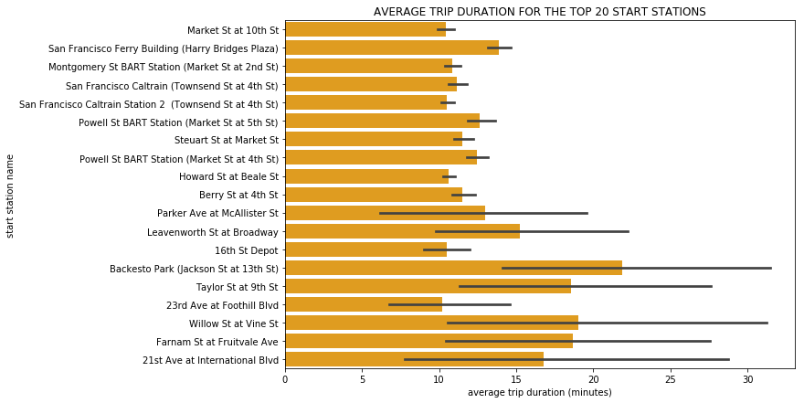

```python
# a reference to the dataframe
df_top20st = df_ford[df_ford['start_station_name'].isin(stcounts)]

# step 2 - let seaborn help us out
plt.figure(figsize=[10,7])
sb.barplot(data=df_top20st, y='start_station_name', x='duration_min', color='orange') ;
put_labels('AVERAGE TRIP DURATION FOR THE TOP 20 START STATIONS',
          'average trip duration (minutes)', 'start station name')
```

#### 6B: Start Station and End Station

Let's define a 'journey'. A journey is simply a start-station to end-station pair. It gives a very rough idea of the path taken for each user. Let's ask - which journeys are the most popular? Which start-station and end-station pairs are most frequent in the dataset?

There are a lot of start and end stations. 329 for each, to be exact. Thankfully, we don't care about all of them. We only care about the most frequented ones. To keep clutter to a minimum, we'll only filter the top five most frequented start and end stations.

```python
# Step 1 - filter the dataframe for the top five start stations and top five end stations
top5_start = df_ford['start_station_name'].value_counts(ascending=False)[0:5]
top5_end = df_ford['end_station_name'].value_counts(ascending=False)[0:5]

# a reference to the original df, but filtered
df_topjourneys = df_ford[df_ford['start_station_name'].isin(top5_start.index)]
df_topjourneys = df_topjourneys[df_topjourneys['end_station_name'].isin(top5_end.index)]
```

```python
# Step 2 - group
topj_counts = df_topjourneys.groupby(['start_station_name', 'end_station_name']).count()['duration_sec']
topj_counts = topj_counts.reset_index(name='end_station_counts')
#topj_counts
```

```python
# Step 3 - pivot the table
topj_counts = topj_counts.pivot(index = 'start_station_name', columns = 'end_station_name',
                            values = 'end_station_counts') ;
#topj_counts
```

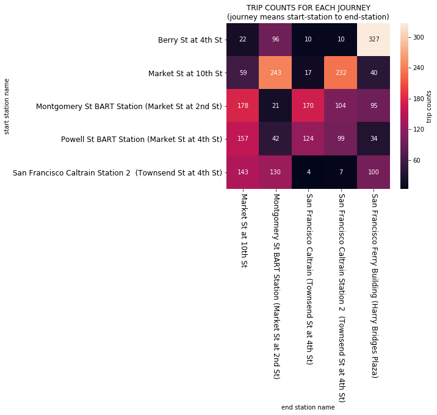

```python
# Step 4 - make a heatmap of journey counts
plt.figure(figsize=[6,5])
ax = sb.heatmap(topj_counts, annot = True, fmt = 'd', cbar_kws = {'label' : 'trip counts'}) ;
ax.set(xlabel='end station name', ylabel='start station name',
       title='TRIP COUNTS FOR EACH JOURNEY\n(journey means start-station to end-station)')
plt.yticks(rotation=0, size=12)
plt.xticks(rotation=-90, size=12) ;
```

As we can see in the upper-right corner, the most popular journey started from Berry at 4th Street, and ended at San Francisco Ferry Building (Harry Bridges Plaza). This journey was the most 'popular' in the sense that it has the highest number of trip counts.

### Talk about some of the relationships you observed in this part of the investigation. How did the feature(s) of interest vary with other features in the dataset?

> What stood out to me is the fact that the start hours and end hour counts have roughly the same shape, and even peak and taper at the same hours. We saw one explanation for this - that it reinforces the fact that most of the trip durations were fairly short, and suggests that this specific Bike-share programme had good logistics.

> There were also other interesting points to note.
> - The longest trip durations were due to younger users
> - Users of unspecified gender had the longest average trip durations, if we group by gender.
> - 18-year-old users especially had the longest average trip duration. However, when we grouped the ages into bins, the 78-87 year olds had the longest average trip duration.
> - We noticed that the counts for start hour was bimodal for the entire dataset. However, this bimodality vanished for the older users. This lent credence to the claim that the bimodality is due to users rushing to and from work.

### Did you observe any interesting relationships between the other features (not the main feature(s) of interest)?

> A few were observed...
> - Exactly zero Customers used the Bike-Share-for-All plan.
> - Tuesday and Thursday seemed to consistently boast the highest trip-taking rates, regardless of age group.

## Multivariate Exploration

### Multivariate plot 1: Average trip duration for each start hour, for each day

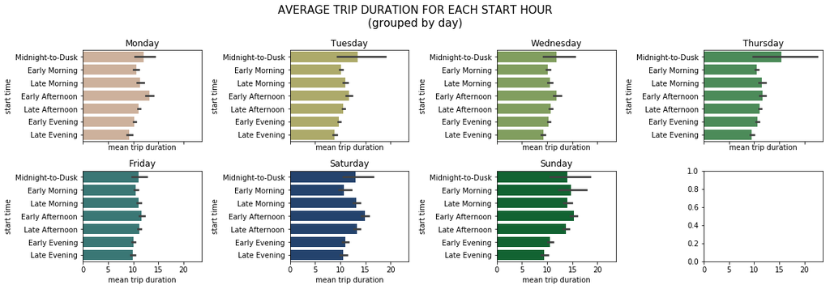

```python
# plt
weekdays = df_ford['weekday'].value_counts().sort_index().index
weekday_colors = sb.color_palette('gist_earth_r')+sb.color_palette('Greens_r')

count = 0
rows, columns = 2,4
fig, axes = plt.subplots(rows,columns,sharex=True)
for i in range(rows):
    for j in range(columns):
        if count<len(weekdays):
            filtered_df = df_ford[df_ford['weekday']==weekdays[count]]
            axes[i][j].figure.set_size_inches([16,5])
            p = sb.barplot(data=filtered_df, y='part_of_day', x='duration_min',
                                  color=weekday_colors[count], ax=axes[i][j])
            p.set(title=weekdays[count], xlabel='mean trip duration', ylabel='start time')
        count += 1

plt.tight_layout()
plt.suptitle('AVERAGE TRIP DURATION FOR EACH START HOUR\n(grouped by day)', x=0.5, y=1.1, size=15)
plt.show()
```

### Multivariate plot 2: Average trip duration against start time for each user age group

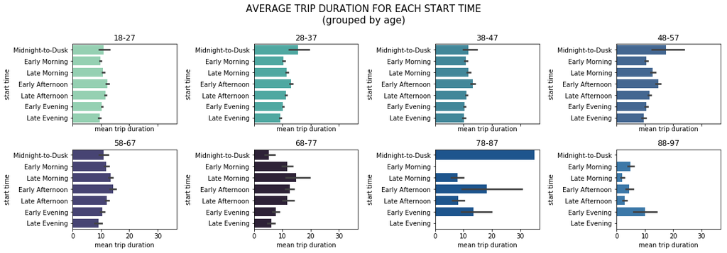

```python
# plt
age_groups = df_ford['age_group'].value_counts().sort_index().index
age_colors = sb.color_palette('mako_r')+sb.color_palette('Blues_r')

count = 0
rows, columns = 2,4
fig, axes = plt.subplots(rows,columns,sharex=True)
for i in range(rows):
    for j in range(columns):
        if count<len(age_groups):
            filtered_df = df_ford[df_ford['age_group']==age_groups[count]]
            axes[i][j].figure.set_size_inches([16,5])
            p = sb.barplot(data=filtered_df, y='part_of_day', x='duration_min',
                                  color=age_colors[count], ax=axes[i][j])
            p.set(title=age_groups[count], xlabel='mean trip duration', ylabel='start time')
        count += 1

plt.suptitle('AVERAGE TRIP DURATION FOR EACH START TIME\n(grouped by age)', x=0.5, y=1.1, size=15)
plt.tight_layout()
plt.show()
```

There isn't a clear trend connecting all age groups but perhaps we don't have to connect all age groups. If we ignore the Midnight-to-Dusk trips, we can see that as the users get older the mean trip duration lengthens in the Late Morning period. One possible explanation for this is that the older users were not commuting to work, but instead perhaps taking recreational strolls, leisurely rides.

The trend breaks for the oldest users.

### Multivariate plot 3: User age and average trip duration, for each weekday.

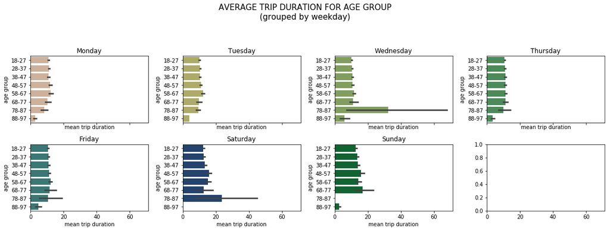

```python
# barplt
weekdays = df_ford['weekday'].value_counts().sort_index().index
weekday_colors = sb.color_palette('gist_earth_r')+sb.color_palette('Greens_r')

count = 0
rows, columns = 2,4
fig, axes = plt.subplots(rows,columns,sharex=True)
for i in range(rows):
    for j in range(columns):
        if count<len(weekdays):
            filtered_df = df_ford[df_ford['weekday']==weekdays[count]]
            axes[i][j].figure.set_size_inches([16,5])
            p = sb.barplot(data=filtered_df, y='age_group', x='duration_min',
                                  color=weekday_colors[count], ax=axes[i][j])
            p.set(title=weekdays[count], xlabel='mean trip duration', ylabel='age group')
        count += 1

plt.suptitle('AVERAGE TRIP DURATION FOR AGE GROUP\n(grouped by weekday)', x=0.5, y=1.2, size=15)
plt.tight_layout()
plt.show()
```

There doesn't seem to be any interesting trend here, other than the average trip duration of the older users spiking up every now and then - particularly on Wednesday and on weekends. For the rest, there's barely any noticeable change.

A scatterplot will show us more detail.

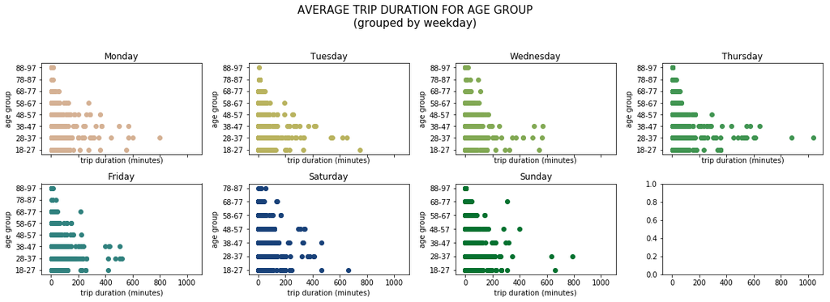

```python
# scatterplt
weekdays = df_ford['weekday'].value_counts().sort_index().index
weekday_colors = sb.color_palette('gist_earth_r')+sb.color_palette('Greens_r')

count = 0
rows, columns = 2,4
fig, axes = plt.subplots(rows,columns,sharex=True)
for i in range(rows):
    for j in range(columns):
        if count<len(weekdays):
            filtered_df = df_ford[df_ford['weekday']==weekdays[count]]
            axes[i][j].figure.set_size_inches([16,5])
            axes[i][j].scatter(data=filtered_df, y='age_group', x='duration_min',
                            color=weekday_colors[count])
            axes[i][j].set(title=weekdays[count], xlabel='trip duration (minutes)', ylabel='age group')
        count += 1

plt.suptitle('AVERAGE TRIP DURATION FOR AGE GROUP\n(grouped by weekday)', x=0.5, y=1.15, size=15)
plt.tight_layout()
plt.show()
```

### Multivariate plot 4: Start station, End station and Average trip duration

Let's ask - which journeys took the longest average time? A journey is simply a start station and end station pair.

The heatmap is inspired by [Udacity's own code](https://classroom.udacity.com/nanodegrees/nd002-alg-t2/parts/cd0016/modules/7e1817ca-5505-4583-b772-2e50d49a14a0/lessons/ls2237/concepts/d629b721-fc26-4f4f-a7d5-2af2d6f17bff). Much credit goes to Udacity.

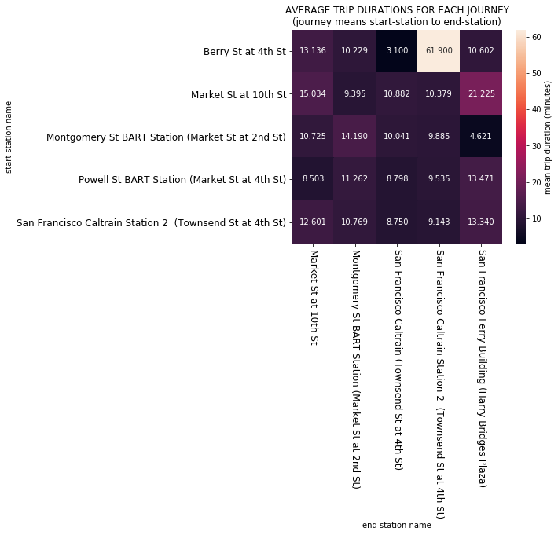

```python
# difficult to pull off.
plt.figure(figsize=[6,5])

cat_means = df_topjourneys.groupby(['end_station_name', 'start_station_name']).mean()['duration_min']
cat_means = cat_means.reset_index(name = 'average_trip_duration') ;
cat_means = cat_means.pivot(index = 'start_station_name', columns = 'end_station_name',
                            values = 'average_trip_duration') ;
ax = sb.heatmap(cat_means, annot = True, fmt = '.3f', cbar_kws = {'label' : 'mean trip duration (minutes)'}) ;
ax.set(xlabel='end station name', ylabel='start station name',
       title='AVERAGE TRIP DURATIONS FOR EACH JOURNEY\n(journey means start-station to end-station)')
plt.yticks(rotation=0, size=12)
plt.xticks(rotation=-90, size=12) ;
```

It would've been wonderful to explore a lot more about the journeys, but we have a reasonable idea of the relationships between variables at this point.

### Were there any interesting or surprising interactions between features?

> There weren't any interesting or surprising interactions.

## Conclusions

> Correlations with trip duration showed up more clearly in bivariate explorations.
> - We saw that most of the users were male.
> - We saw that the longest trip durations were associated with both the youngest and oldest users.
> - We saw that the trip duration (counts or average) correlated with user age, user type, start hour, weekday, and even start station, though the trends weren't always extreme.
> - We saw that the number of trips taken spiked in the Early Morning and Late Afternoon periods, and found evidence suggesting that it was due to users rushing to and from work.
> - We saw that the number of trips taken spiked on Tuesdays and Thursdays but there didn't seem to be enough data to draw anything meaningful from that.
> - We also remarked on how interesting it was that the counts for the start hour and end hour looked very similar and peaked at the same times. We suggested that this indicated the good logistics of the Bike-sharing programme, and the shorter trip durations overall.

.